# Exploring Hotel Review Data from Trip Advisor

I wanted to explore hotel review data for a few hotels from [Trip Advisor](http://www.tripadvisor.com). I have described scraping data for 3 hotels [here](http://notesofdabbler.github.io/201408_hotelReview/scrapeTripAdvisor.html). The hotels considered are (disclaimer: choice of hotels is random):

- [J. W. Marriott, Indianapolis](http://www.tripadvisor.com/Hotel_Review-g37209-d1762915-Reviews-JW_Marriott_Indianapolis-Indianapolis_Indiana.html)
- [Conrad, Indianapolis](http://www.tripadvisor.com/Hotel_Review-g37209-d576787-Reviews-Conrad_Indianapolis-Indianapolis_Indiana.html)
- [Hampton Inn Indanapolis Northwest - Park 100, Indianapolis](http://www.tripadvisor.com/Hotel_Review-g37209-d1236866-Reviews-Hampton_Inn_Indianapolis_Northwest_Park_100-Indianapolis_Indiana.html)

## Loading and Reviewing Data

```r
# set working directory
setwd("~/notesofdabbler/githubfolder/blog_notesofdabbler/hotelReview/")

library(dplyr)
```

```r
library(lubridate)
library(ggplot2)
library(tm)
library(scales)
library(topicmodels)

# load data for a hotel
# currently 3 datasets available from scraping trip advisor data
#    1. J W Marriott, Indianapolis (label: jwmarriott)
#    2. Hampton Inn Indianapolis Northwest -100 (label: hamptoninn)
#    3. Conrad Indianapolis (label: conrad)
#

hotellist=c("jwmarriott","conrad","hamptoninn")


# load hotel review data for each hotel and return the following for each hotel
# * Data frame with hotel reviews
# * Top 3 records
# * Number of reviews in dataset
# * frequency of different ratings
dfrating.l=lapply(hotellist,
                  function(x) {
                      filenm=paste("dfrating_",x,".Rda",sep="")
                      load(filenm)
                      return(list(dfrating=dfrating,
                                  top3records=head(dfrating,3),
                                  numrevs=nrow(dfrating),
                                  freqRating=table(dfrating$ratingnum)))
                                         })
names(dfrating.l)=hotellist

dfrating.l[["jwmarriott"]]$top3records
```

```
##            id
## 1 rn220694072
## 2 rn220524586
## 3 rn220162069
##                                                        topquote   ratingdt
## 1 Excellent Hotel--especially if you can get a government rate! 2014-08-09
## 2                                Close to football and baseball 2014-08-08
## 3                                   Best hotel experience ever! 2014-08-07
##         rating
## 1 5 of 5 stars
## 2 5 of 5 stars
## 3 5 of 5 stars
##                                                                                                                                                                                                                                                                                                          …
## 1                  \nJW Marriott Hotels are among my favorite in the Marriott chain and on the rare occasion that they offer a government rate, they are an excellent place to stay. One of the largest hotels in the Midwest, the JW Indianapolis is about 5 blocks from the center of Indianapolis. My …
## 2              \nThis property is close to their minor league baseball team and just a short distance from Lucas Field, home of the Colts. It is across the street from the convention center and government buildings. It is about 4 -5 blocks from the city center. The staff is exceptionally friendly…
## 3 \nAll the services from hotel staff, to the FedEx office to the restaurants were top notch! All the wait staff for both the restaurants gave excellent service as well as personable service! The Fedex store was extremely helpful and sympathetic to my crazy stressful circumstance of my books not …
##   ratingnum       id2
## 1         5 220694072
## 2         5 220524586
## 3         5 220162069
##                                                                                                                                                                                                                                                                                                          …
## 1 \nJW Marriott Hotels are among my favorite in the Marriott chain and on the rare occasion that they offer a government rate, they are an excellent place to stay. One of the largest hotels in the Midwest, the JW Indianapolis is about 5 blocks from the center of Indianapolis. My room was exceptio…
## 2                                                                                                                                                                                              \nThis property is close to their minor league baseball team and just a short distance from Lucas Field, h…
## 3                                                                                                                                                                                                                                                       \nAll the services from hotel staff, to the FedEx…
```

```r
dfrating.l[["jwmarriott"]]$numrevs
```

```
## [1] 808
```

```r
dfrating.l[["jwmarriott"]]$freqRating
```

```
##
##   1   2   3   4   5
##  11  18  57 156 566
```

```r
dfrating.l[["conrad"]]$top3records
```

```
##            id                 topquote   ratingdt       rating
## 1 rn220562473      Spectacular service 2014-08-08 5 of 5 stars
## 2 rn220387742  Excellent staff service 2014-08-07 5 of 5 stars
## 3 rn220109249 A good choice downtown.  2014-08-06 4 of 5 stars
##                                                                                                                                                                                                                                                                                                          …
## 1         \nLea at the concierge desk was incredibly helpful. She gave us wonderful advice on dining and made us feel totally welcome. I have stayed in Indy dozens of times when I was traveling for business before I retired and only recently tried the Conrad . The bite is lovely, well situated an…
## 2                                                                                 \nAll of the staff were excellent! From the house keepers to the front desk, they were great. The staff near the front door and outside were always anticipating our needs and offering to get our car, to give directi…
## 3 \nTo be honest there is a paucity of decent hotels in Indy.\nConrad (the upper market Hiltons) are generally good but you can see they come from 4* aiming at 5 as their isn't the inherent service focus of the full 5* hotels.\nAnyway. This ones pretty good. It benefits from having a Capital Gril…
##   ratingnum       id2
## 1         5 220562473
## 2         5 220387742
## 3         4 220109249
##                                                                                                                                                                                                                                                                                                          …
## 1                                                                                                                                                                                                                                                                \nLea at the concierge desk was incredib…
## 2                                                                                                                                                                                                                                                                                                        …
## 3 \nTo be honest there is a paucity of decent hotels in Indy. Conrad (the upper market Hiltons) are generally good but you can see they come from 4* aiming at 5 as their isn't the inherent service focus of the full 5* hotels. Anyway. This ones pretty good. It benefits from having a Capital Grille…
```

```r
dfrating.l[["conrad"]]$numrevs
```

```
## [1] 614
```

```r
dfrating.l[["conrad"]]$freqRating
```

```
##
##   1   2   3   4   5
##   3  17  35 122 437
```

```r
dfrating.l[["hamptoninn"]]$top3records
```

```
##            id                                                topquote
## 1 rn219975597 Clean place, friendly staff, close to convention center
## 2 rn218377442                   It's a Hampton, but a nicer than many
## 3 rn217368068                                           Great Service
##     ratingdt       rating
## 1 2014-08-06 4 of 5 stars
## 2 2014-07-29 4 of 5 stars
## 3 2014-07-24 5 of 5 stars
##                                                                                                                                                                                                                                                                                                          …
## 1                               \nI traveled here for work, spending four nights in the same room. There were multiple events in town and this place was very busy. They ran out of shaving cream, something they normally have at the front desk or in the suite shop, but there is a CVS about four blo…
## 2 \nComfortable, clean, attractive hotel with nice lobby. They have a happy hour with food, all free on a few midweek nights. Not many restaurants nearby except fast food but within 3 miles there are several decent places. The only down side to this hotel is the quality of exercise equipment. It …
## 3                                                                                                                          \nBusiness or pleasure this is a good place to stay. Service was excellent, staff attentive, and rooms are clean. Check in and out was profession and fast. The breakfast had …
##   ratingnum       id2
## 1         4 219975597
## 2         4 218377442
## 3         5 217368068
##                                                                                                                                                                                                                                                                                                          …
## 1 \nI traveled here for work, spending four nights in the same room. There were multiple events in town and this place was very busy. They ran out of shaving cream, something they normally have at the front desk or in the suite shop, but there is a CVS about four blocks away, so I was able to get…
## 2                                                                                                                                                                                                                                                                                                        …
## 3                                                                                                                                                                                                                                                                                                        …
```

```r
dfrating.l[["hamptoninn"]]$numrevs
```

```
## [1] 196
```

```r
dfrating.l[["hamptoninn"]]$freqRating
```

```
##
##   2   3   4   5
##   1  10  36 149
```

## Ratings Over Time

These 3 hotels are listed among the top 5 hotels in Indianapolis. So most of the ratings are 4 or 5 for these. Next, I have plotted % of reviews with a given rating over time

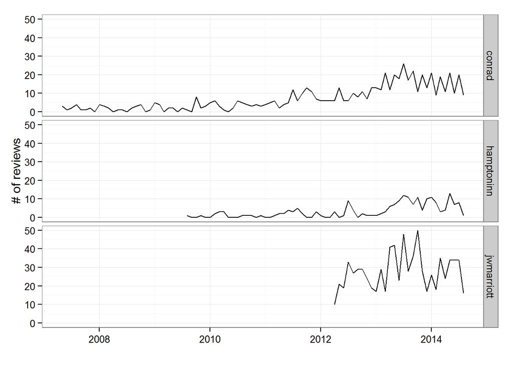

```r
# function to get number of reviews and % of reviews with a rating
getrev.bymon=function(hotel){

  # get review data
  dfrating=dfrating.l[[hotel]]$dfrating

  # create a month label
  dfrating$yrmon=floor_date(dfrating$ratingdt,"month")

  # create sequence of months
  yrmon=unique(dfrating$yrmon)
  yrmonseq=seq(min(yrmon),max(yrmon),by="months")

  # yr-month and rating combinations
  yrmon.rating=expand.grid(yrmon=yrmonseq,ratingnum=c(1,2,3,4,5))

  # get % of reviews for each rating by month
  dfrating.bymon=dfrating%>%group_by(yrmon,ratingnum)%>%summarize(count=n())
  dfrating.bymon.agg=dfrating.bymon%>%group_by(yrmon)%>%summarize(countfull=sum(count))
  dfrating.bymon=merge(dfrating.bymon,dfrating.bymon.agg,c("yrmon"))
  dfrating.bymon$pctrating=dfrating.bymon$count/dfrating.bymon$countfull


  dfrating.bymon=merge(yrmon.rating,dfrating.bymon,by=c("yrmon","ratingnum"),all.x=TRUE)
  dfrating.bymon$pctrating[is.na(dfrating.bymon$pctrating)]=0
  dfrating.bymon$count[is.na(dfrating.bymon$count)]=0
  dfrating.bymon$countfull[is.na(dfrating.bymon$countfull)]=0

  dfrating.bymon$hotel=hotel

  # get number of reviews by month
  dfrating.bymon.revs=dfrating.bymon%>%group_by(yrmon)%>%summarize(numrevs=sum(count))
  dfrating.bymon.revs$hotel=hotel

  return(list(dfrating.bymon=dfrating.bymon,dfrating.bymon.revs=dfrating.bymon.revs))

}

dfrating.bymon.l=lapply(hotellist,function(x) getrev.bymon(x))


# plot number of reviews by year-month
dfrating.bymon.revs=do.call(rbind,lapply(dfrating.bymon.l,function(x) x$dfrating.bymon.revs))
p=ggplot(dfrating.bymon.revs,aes(x=yrmon,y=numrevs))+geom_line()+facet_grid(hotel~.)
p=p+xlab("")+ylab("# of reviews")
p=p+theme_bw()
p
```

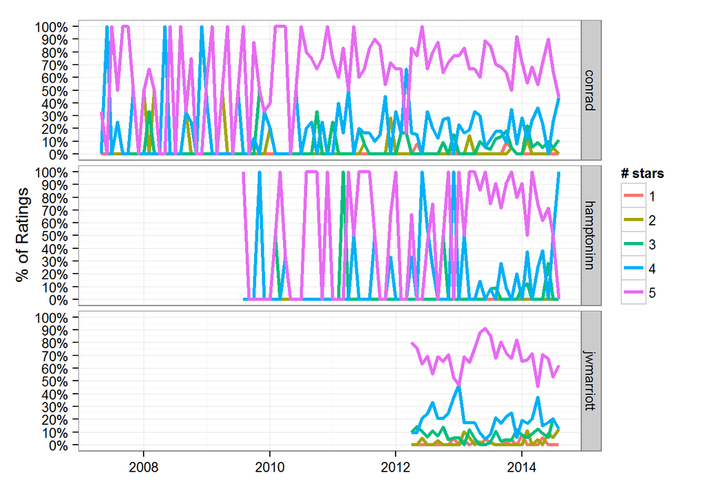

```r
# plot % of reviews for each rating by year-month
dfrating.bymon=do.call(rbind,lapply(dfrating.bymon.l,function(x) x$dfrating.bymon))
p=ggplot(dfrating.bymon,aes(x=yrmon,y=pctrating,color=factor(ratingnum)))+geom_line(size=1.1)
p=p+facet_grid(hotel~.)
p=p+xlab("")+ylab("% of Ratings")
p=p+scale_y_continuous(breaks=seq(0,1,0.1),labels=percent)+scale_color_discrete(name="# stars")
p=p+theme_bw()
p
```

The more choppy areas of % of ratings plot correspond to periods with very less reviews.

## Words in Top Quote for a Review

I wanted to check out the top words occuring in top quotes associated with review for each star rating. Though I show the top words for each star rating, we should remember that the frequency of lower star ratings in data is low.

```r
# Explore top level quotes for each rating

# function to get document-term matrix from hotel review data for a given hotel
getDTM=function(dftxt){

  # code adapted from http://www.rdatamining.com/examples/text-mining

  txtcorpus=Corpus(VectorSource(dftxt))
  #inspect(txtcorpus[1:5])

  txtcorpus.cl=tm_map(txtcorpus,tolower)
  txtcorpus.cl=tm_map(txtcorpus.cl,removePunctuation)
  txtcorpus.cl=tm_map(txtcorpus.cl,removeNumbers)

  mystopwords=c(stopwords("english"),"hotel","staff","room","rooms","indianapolis","marriott","conference",
                "convention","indy","downtown","hampton","stay","stayed","inn","conrad")
  txtcorpus.cl=tm_map(txtcorpus.cl,removeWords,mystopwords)
  #dictCorpus=txtcorpus.cl
  #txtcorpus.cl=tm_map(txtcorpus.cl,stemDocument)
  #txtcorpus.cl=tm_map(txtcorpus.cl,stemCompletion,dictionary=dictCorpus)

  dtm=DocumentTermMatrix(txtcorpus.cl)

  dtm.m=as.matrix(dtm)

  return(dtm.m)
}

getTopTerms=function(hotel){

  # get review data
  dfrating=dfrating.l[[hotel]]$dfrating

  minrating=min(dfrating$ratingnum)
  maxrating=max(dfrating$ratingnum)
  tfreq.l=as.list(rep(NA,maxrating-minrating+1))

  # of frequent words to retain
  numterms=20

  rating=maxrating+1

  for(i in 1:(maxrating-minrating+1)){

    rating=rating-1
    #sprintf("Processing data for %s stars",rating)

    dftxt=dfrating$topquote[dfrating$ratingnum==rating]

    dtm.m=getDTM(dftxt)

    tfreq=colSums(dtm.m)
    tfreq.l[[i]]=names(sort(tfreq,decreasing=TRUE)[1:numterms])
  }

  topTerms=do.call(cbind,tfreq.l)
  colnames(topTerms)=paste(seq(maxrating,minrating)," star")

  return(list(dtm.m=dtm.m,topTerms=topTerms))

}

topTerms.l=lapply(hotellist,function(x) getTopTerms(x))
names(topTerms.l)=hotellist

topTerms.l[["jwmarriott"]]$topTerms
```

```
##       5  star       4  star       3  star          2  star
##  [1,] "great"       "nice"        "good"           "bad"
##  [2,] "service"     "great"       "nice"           "disappointing"
##  [3,] "excellent"   "good"        "great"          "service"
##  [4,] "best"        "location"    "expected"       "slow"
##  [5,] "location"    "place"       "location"       "amenities"
##  [6,] "nice"        "service"     "really"         "around"
##  [7,] "place"       "best"        "service"        "available"
##  [8,] "wonderful"   "excellent"   "big"            "back"
##  [9,] "experience"  "beautiful"   "business"       "bellman"
## [10,] "beautiful"   "new"         "doesnt"         "beware"
## [11,] "fantastic"   "property"    "price"          "building"
## [12,] "property"    "really"      "time"           "charges"
## [13,] "business"    "classy"      "bad"            "cleaning"
## [14,] "good"        "everything"  "chaos"          "desk"
```

[output cut: 27 more lines]

```r
topTerms.l[["conrad"]]$topTerms
```

```
##       5  star      4  star       3  star          2  star
##  [1,] "great"      "nice"        "nice"           "disappointing"
##  [2,] "best"       "great"       "four"           "great"
##  [3,] "excellent"  "good"        "service"        "service"
##  [4,] "service"    "location"    "better"         "property"
##  [5,] "location"   "service"     "brand"          "attention"
##  [6,] "wonderful"  "excellent"   "class"          "bad"
##  [7,] "amazing"    "friendly"    "dont"           "brunch"
##  [8,] "perfect"    "hilton"      "expectations"   "customer"
##  [9,] "weekend"    "best"        "first"          "decent"
## [10,] "experience" "city"        "good"           "define"
## [11,] "nice"       "perfect"     "seasons"        "dirty"
## [12,] "one"        "value"       "accommodations" "easter"
## [13,] "beautiful"  "close"       "age"            "ever"
## [14,] "top"        "comfortable" "amenities"      "expected"
```

[output cut: 27 more lines]

```r
topTerms.l[["hamptoninn"]]$topTerms
```

```
##       5  star       4  star       3  star      2  star
##  [1,] "great"       "clean"       "nice"       "expected"
##  [2,] "best"        "great"       "industrial" NA
##  [3,] "service"     "nice"        "adequate"   NA
##  [4,] "clean"       "place"       "area"       NA
##  [5,] "nice"        "comfortable" "complex"    NA
##  [6,] "place"       "good"        "essentials" NA
##  [7,] "excellent"   "service"     "floor"      NA
##  [8,] "experience"  "friendly"    "frig"       NA
##  [9,] "friendly"    "new"         "great"      NA
## [10,] "one"         "will"        "lacking"    NA
## [11,] "comfortable" "act"         "located"    NA
## [12,] "good"        "amenities"   "location"   NA
## [13,] "highly"      "away"        "microwave"  NA
## [14,] "location"    "back"        "missing"    NA
## [15,] "new"         "budget"      "new"        NA
## [16,] "property"    "center"      "next"       NA
## [17,] "value"       "choice"      "number"     NA
## [18,] "amazing"     "class"       "okay"       NA
## [19,] "comfort"     "close"       "park"       NA
## [20,] "inns"        "convenient"  "short"      NA
```

One thing I want to explore in the future is to train such a data set (features being words and response being rating) using Trip Advisor reviews and use it to predict rating in some other area (such as tweets on a topic).

## Exploring Full Review Text

Next, I wanted to explore the full text review to see if there are themes. Right now, I am not too familiar with topic model packages (on my near term todo list). For now, I took a more simpler approach of just using k-means clustering of words using term document term matrix to find cluster of words. Here I just picked 5 clusters and haven’t checked what the right number of clusters are.

```r
# Further investigation of high star rating using full reviews for a hotel

# functiont to cluster words from term document matrix of full reviews for a hotel

getClust=function(hotel){

  # load hotel full review data
  dfrating=dfrating.l[[hotel]]$dfrating

  dftxt=dfrating$fullrev[dfrating$ratingnum>=4]
  dtm.m=getDTM(dftxt)

  # clustering of words to detect themes/topics

  set.seed(1234)
  txtclust=kmeans(t(dtm.m),5)

  # size of clusters
  txtclust$size

  # within and total sum of squares
  txtclust$totss
  txtclust$withinss

  # get list of frequent terms in each cluster
  clustTerms=as.list(rep(NA,5))

  termlist=colnames(dtm.m)
  for(i in 1:5){
    termlist.filt=termlist[txtclust$cluster == i]
    tfreq=colSums(dtm.m)
    tfreq.filt=sort(tfreq[termlist.filt],decreasing=TRUE)
    clustTerms[[i]]=names(tfreq.filt[1:20])
  }
  clust.topic=do.call(cbind,clustTerms)
  clust.topic[is.na(clust.topic)]=""
  colnames(clust.topic)=c("cluster 1","cluster 2","cluster 3","cluster 4","cluster 5")

  # print list of frequent terms in each cluster
  return(list(txtclust=txtclust,clust.topic=clust.topic))

}

clust.topic=lapply(hotellist,function(x) getClust(x))
names(clust.topic)=hotellist

clust.topic[["jwmarriott"]]$clust.topic
```

```
##       cluster 1       cluster 2     cluster 3 cluster 4    cluster 5
##  [1,] "notch"         "location"    "great"   "amazing"    "floor"
##  [2,] "care"          "center"      "service" "definitely" "one"
##  [3,] "skywalk"       "restaurants" "nice"    "ever"       "well"
##  [4,] "decorated"     "city"        "good"    "make"       "clean"
##  [5,] "courteous"     "will"        ""        "much"       "view"
##  [6,] "efficient"     "breakfast"   ""        "fantastic"  "time"
##  [7,] "options"       "place"       ""        "staying"    "friendly"
##  [8,] "pleased"       "hotels"      ""        "close"      "food"
##  [9,] "thanks"        "beautiful"   ""        "several"    "also"
## [10,] "travel"        "area"        ""        "free"       "comfortable"
## [11,] "attended"      "really"      ""        "level"      "bar"
## [12,] "beyond"        "everything"  ""        "say"        "just"
## [13,] "week"          "best"        ""        "enjoyed"    "excellent"
## [14,] "anyone"        "lounge"      ""        "got"        "night"
## [15,] "entire"        "helpful"     ""        "weekend"    "get"
## [16,] "exceptional"   "restaurant"  ""        "went"       "desk"
## [17,] "accommodating" "day"         ""        "elevator"   "lobby"
## [18,] "expected"      "wonderful"   ""        "located"    "large"
## [19,] "experienced"   "like"        ""        "nights"     "front"
## [20,] "prices"        "back"        ""        "trip"       ""
```

```r
clust.topic[["conrad"]]$clust.topic
```

```
##       cluster 1    cluster 2     cluster 3 cluster 4 cluster 5
##  [1,] "every"      "worth"       "service" "great"   "location"
##  [2,] "business"   "getaway"     "nice"    ""        "one"
##  [3,] "recommend"  "plus"        ""        ""        "comfortable"
##  [4,] "always"     "luxury"      ""        ""        "clean"
##  [5,] "amazing"    "superb"      ""        ""        "time"
##  [6,] "perfect"    "impressed"   ""        ""        "well"
##  [7,] "back"       "pricey"      ""        ""        "bathroom"
##  [8,] "top"        "anniversary" ""        ""        "also"
##  [9,] "beds"       "favorite"    ""        ""        "good"
## [10,] "distance"   "noise"       ""        ""        "will"
## [11,] "ever"       "pretty"      ""        ""        "excellent"
## [12,] "definitely" "standard"    ""        ""        "friendly"
## [13,] "enjoyed"    "anyone"      ""        ""        "get"
## [14,] "made"       "anywhere"    ""        ""        "night"
## [15,] "make"       "chose"       ""        ""        "desk"
## [16,] "grill"      "complaint"   ""        ""        "bed"
## [17,] "located"    "indoor"      ""        ""        "just"
## [18,] "city"       "now"         ""        ""        "wonderful"
## [19,] "hilton"     "sleep"       ""        ""        "valet"
## [20,] "weekend"    "areas"       ""        ""        "shower"
```

```r
clust.topic[["hamptoninn"]]$clust.topic
```

```
##       cluster 1   cluster 2    cluster 3       cluster 4     cluster 5
##  [1,] "clean"     "excellent"  "close"         "good"        "lot"
##  [2,] "breakfast" "experience" "restaurants"   "pool"        "day"
##  [3,] "great"     "right"      "located"       "comfortable" "little"
##  [4,] "nice"      "wonderful"  "complimentary" "friendly"    "new"
##  [5,] "area"      "bit"        "definitely"    "quiet"       "nights"
##  [6,] "well"      "enjoyed"    "access"        "location"    "ive"
##  [7,] ""          "find"       "offered"       "time"        "every"
##  [8,] ""          "next"       "perfect"       "one"         "kept"
##  [9,] ""          "able"       "really"        "will"        "lobby"
## [10,] ""          "highly"     "extremely"     "night"       "can"
## [11,] ""          "make"       "many"          "desk"        "fresh"
## [12,] ""          "food"       "eat"           "hot"         "need"
## [13,] ""          "town"       "pleasant"      "service"     "park"
## [14,] ""          "weekend"    "visit"         "helpful"     "dont"
## [15,] ""          "near"       "several"       "free"        "found"
## [16,] ""          "price"      "beautiful"     "get"         "minutes"
## [17,] ""          "recently"   "minute"        "easy"        "morning"
## [18,] ""          "spacious"   "nearby"        "front"       "within"
## [19,] ""          "asked"      "travel"        "trip"        "coffee"
## [20,] ""          "come"       "loved"         "always"      "hilton"
```

I was finding it hard to assign themes that differentiate clusters. Perhaps I need to do a better job filtering words or play around more with parameters for clustering or check out algorithms for topic models. Nevertheless, this was a fun exercise.

## Session Info

All analysis was done in RStudio 0.98.994